# plant systems genetics:

January 2017

## Overview

Systems genetics is an approach to understand the flow of biological information that underlies complex traits.

how to relate phenotype to genotype

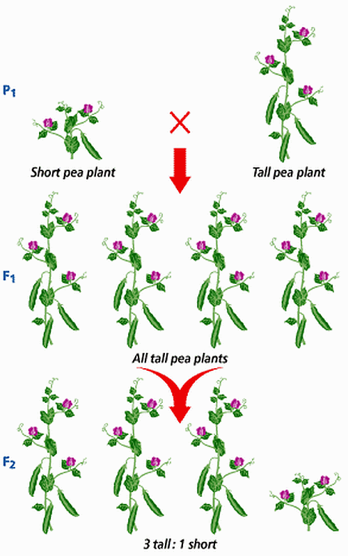

- gene mapping (QTL or linkage analysis)
- genomic selection (MAS)

with changing technology

- laboratory protocols
- statistical methods
- computational tools

Figure: plantcellbiology.masters.grkraj.org

## Approach in these talks

mix of presentation style to plant-based audience

- theory
  - set the stage
  - show big picture
- applied: using R packages
  - [qtl](http://rqtl.org): basic gene mapping
  - [rrBLUP](http://potatobreeding.cals.wisc.edu/software/): genome-wide prediction & GWAS
  - [qtl2](http://kbroman.org/qtl2/): high throughput gene mapping

## Evolution of laboratory protocol

genetic information (genotype)

- genetic markers discovered by accident (RFLP)
- dense sets of polymorphic markers (SNP, GBS)
- whole genomes sequencing

trait information (phenotype)

- physiological (internal) & environmental (external) measurements
- molecules and images
- inexpensive, high volume assays on 100s or 1000s of plants

(individual cell technologies not covered here)

## Evolution of statistical methods

- experimental design: how populations are created
  - two-founder experiments (backcross, intercross)
  - advanced crosses (RILs)
- model selection: how phenotypes relate to genotypes
  - single marker regressions & interval mapping (QTL)
  - association mapping (including GWAS)
  - account for non-locus genetic effects
- estimation and prediction
  - genetic action (additive, dominance, epistasis)
  - marker assisted selection (MAS)
  - genomic selection

## More on statistical methods

multi-parent populations (MPP)

- developed over generations
- increased meiotic events
- fine mapping to SNP or small region in one generation

advanced model selection

- whole genome regression models
- random effects to adjust for “missing” heritability
- interactions to model epistasis among identified genomic regions

## Even more on statistical methods

- multiple phenotype
  - leveraging similar biological function
  - correlation and causalty models

## Evolution of computational tools

Advances in measurement, design and analysis would be academic without advances in computational technology.

- faster machines -> faster throughput of more stuff
- methods translated into algorithms
  - open source: freely distrubuted, easy to study
- standalone programs
- packages in language systems (R or Python or Matlab)
- interconnectivity of algorithms and data resources

## Collaboration systems

dangers of email-based collaboration

- trading large files back and forth (slow, not secure)
- nearly impossible to keep track of versions
- minor updates require repeat sending

modern approach: use email to notify collaborators only

- [GitHub](https://github.com) to share code & ideas with version control
- Box/DropBox & Google Drive to share documents
- iPlant to improve data access & processing efficiency

## Emerging collaboration systems

modular philosophy of layers to separate

- back-end: data and compute processing layer
- middle-ware: analysis methodology layer
- front-end: human interaction and data visualization layer

will enable overlapping communities to

- customize local use
- share data, methods & results with other communities
- off-load data handling & compute headaches

## Goal of system genetics studies

- predict performance of future offspring
  - genomic selection
- estimate genetic architecture of traits
  - genomic locations
  - genetic action on phenotypes

great time to become involved in modern approaches

- many challenges
- many opportunities for substantial contributions
- help unravel important problems in biological systems